# CEE 218X | Assignment 2

Ana Moura-Cook

03 November, 2020

### Introduction

Education is often perceived to be one of the clearest pathways to socio-economic mobility in the United States. But what if access to this education is inherently inequitable? In this study, education outcomes in the San Francisco Bay Area are analyzed to assess how educational attainment and access to online education varies and whether education has, in fact, been a tool for social mobility. With these varying analyses, I hope to paint a holistic picture of the demographic and geospatial access to education.

### Equity Analysis of Educational Attainment by Race in Santa Clara County

To begin the study, I focus on Santa Clara County, the site of both Stanford University and the Silicon Valley that it gave rise to. It would seem that this high-tech hub would have higher levels of education attainment than what is typical nation-wide, but are these degrees distributed equitably by race? To answer this question, I will use American Community Survey data from the 5-year period ending in 2018. This survey is carried out by the Census Bureau, who has seven racial categories: “White Alone,” “Black or African American,” “American Indian and Alaska Native Alone,” “Asian Alone,” “Native Hawaiian and Other Pacific Islander Alone,” “Some Other Race Alone,” and “Two or More Races.” In contrast, the Hispanic/Latinx population is considered an ethnic group, so this population’s outcomes are often grouped with the “White Alone” racial group. However, I want to examine Hispanic/Latinx outcomes separately, so for the purposes of this study I consider Hispanic/Latinx to be the eighth racial group and replace “White Alone” with “White Alone, not Hispanic or Latinx.”

In the code block below, I use the C15002 family of American Community Survey data to get educational attainment in Santa Clara County by gender for each racial group. It’s important to note that only people over 25 years of age are considered in this dataset, so the values will not sum to the County’s total population. Some data wrangling is required to condense the large amount of ACS data into a concise and easy-to-use format. From there, the estimates for each gender are combined so that the analysis is broken down by racial group alone within the county.

```r
# Necessary libraries & census access set-up
library(tidyverse)
library(sf)
library(tigris)
library(leaflet)

# Set up census methods
library(censusapi)
Sys.setenv(CENSUS_KEY="15460c849329f7966070ff3225759c39d0fe7537")

library(tidycensus)
census_api_key("15460c849329f7966070ff3225759c39d0fe7537")

# Get census metadata
acs_vars_2018_5yr <- readRDS("acs_vars_2018_5yr.rds")

# Create a dataframe to summarize the census race labels
census_race_labels <-
  c(
    "White Alone",
    "Black or African American",
    "American Indian and Alaska Native Alone",
    "Asian Alone",
    "Native Hawaiian and Other Pacific Islander Alone",
    "Some Other Race Alone",
    "Two or More Races",
    "White Alone, not Hispanic or Latinx",
    "Hispanic or Latinx"
  )

# Use a loop to get educational attainment by race
bay_educ_race <-
  2:9 %>%                         # Consider the Hispanic/Latinx population separate from "White Alone"
  map_dfr(function(x){
    getCensus(
      name = "acs/acs5",
      vintage = 2018,
      region = "county:085",      # Santa Clara county
      regionin = "state:06",      # California
      vars = paste0("group(C15002",LETTERS[x],")")
    ) %>%                         # Get the census data for each race group householders
      select(!c(GEO_ID,state,NAME) & !ends_with(c("EA","MA","M"))) %>%
      pivot_longer(
        ends_with("E"),
        names_to = "variable",
        values_to = "estimate"
      ) %>%                       # Make it into a longer table with variables & estimates in one column each
      left_join(
        acs_vars_2018_5yr %>%
          select(name, label),
        by = c("variable" = "name")
      ) %>%                       # Add the variables names instead of the C15002 codes
      select(-variable) %>%       # Get rid of the variable field
      separate(
      label,
      into = c(NA,NA,"gender", "education"),
      sep = "!!"
    ) %>%
    filter(!is.na(education)) %>%
    mutate(race = census_race_labels[x]) %>% # Expand the race label
    group_by(county, education, race) %>%
    summarize(estimate = sum(estimate))      # Combine both genders for each race group
  })
```

To visualize these outcomes, I will first look at the overall quantity of each category of educational attainment. As expected from our outside knowledge of Silicon Valley, the majority of people responded that they have obtained a Bachelor’s degree or higher. However, this is slightly lower than the number of with some lower education attainment level combined. That is, there are just under 700,000 people with a Bachelor’s degree or higher, but there are roughly 750,000 people with less than a high school diploma, a high school diploma or equivalent, or some college or associate’s degree. Therefore, my initial “hunch” that the majority of people in Santa Clara County have a college degree is incorrect.

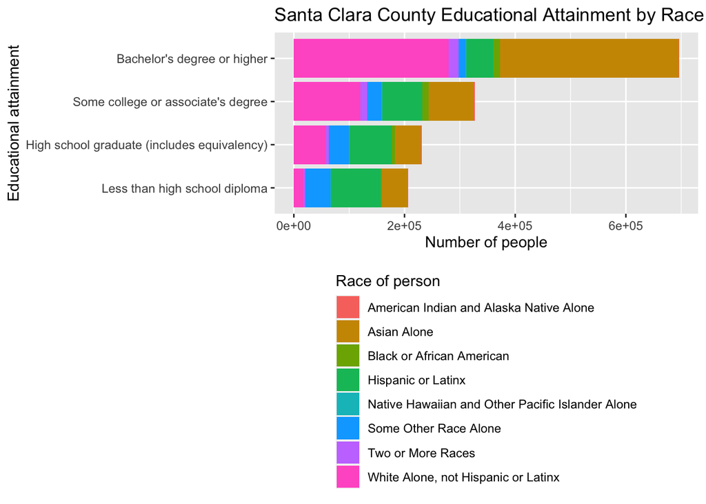

However, this plot makes it challenging to analyze the equity of the distribution of educational attainment levels. An equitable distribution is one in which each level of educational attainment has the same proportion of people from each racial group as is observed in Santa Clara County at large. Therefore, one’s race would have no impact on the likelihood of having a certain educational attainment level.

This filled bar chart below is more useful in this analysis, as it examines the proportion of each racial group within each education level. Furthermore, this proportion is compared to the total racial group distribution in the county, as seen in the first horizontal bar.

It’s *immediately* clear that educational attainment is not equitable. For example, there is a higher-than-representative proportion of White alone people with some college or associates degree and bachelor’s degrees or higher. The proportion of Asian alone people with bachelor’s degrees or higher is similarly higher than proportional. In contrast, the proportion of people who are Hispanic or Latinx with a bachelor’s degree or higher is *much* lower than the overall proportion of Hispanic/Latinx people in the County population and the proportion of Hispanic people with less than a high school diploma is much higher than the overall population proportion.

Therefore, it’s clear that educational outcomes are **not** equitable – Hispanic/Latinx people in particular (as well as the Some Other Race Alone group) are relatively less likely to have a Bachelor’s degree, whereas White and Asian people are relatively more likely to have a Bachelor’s degree.

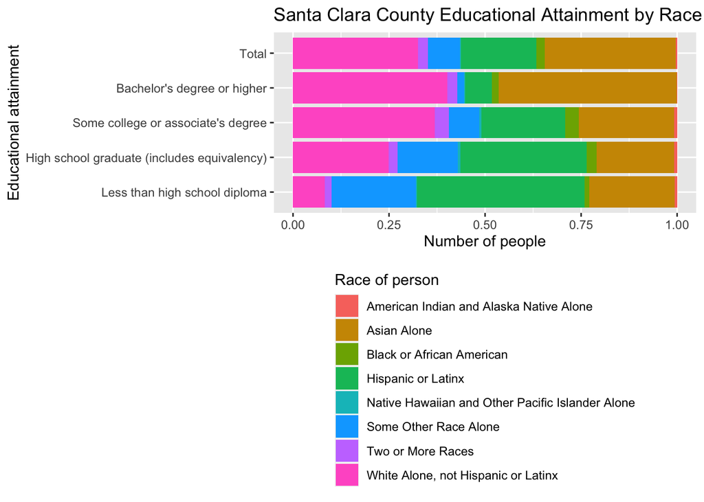

### Geospatial Distribution of K-12 Students with No Internet Access at Home

Education equity in the Bay Area is not just dependent on completed education, but also current access to education. In the COVID-19 pandemic era, access to education is becoming increasingly dependent on internet access as many K-12 schools move completely or partially online. Access to the internet has been a necessary component of K-12 education for many years in the 21st century, however, those without access at home could previously depend on school facilities. With most students now sheltering-in-place at home, home internet access is vital to ensure students’ education is uninterrupted.

In this analysis, I will use the more-detailed Personal Use Microdata Sample (PUMS) from the American Community Survey, which is a small, anonymized set of individual’s responses. Though the sample size is much smaller than the entire population, the individual responses can provide more poignant insights than the aggregated values used in the previous analysis. As before, I use data from the 5-year period ending in 2018.

In the code block below, I first access PUMS data using the `get_pums()` method. The survey responses are lengthy, so it’s important to only access those variables of interest. There are multiple data-related challenges inherent in this analysis: first, the PUMS data is at the household level, so information about access to the internet is reported for each household as a whole. However, there is no single value to capture simply “number of children aged 7-18 in the household.” Therefore, several other variables are used to model this value of interest, including “number of people in the household,” “household presence and age of children,” “number of related children,” “household/family type,” and “presence of subfamilies in household.” This data takes a long time to load, so it is pre-loaded and then saved to an RDS file for later direct access, as shown in the code block below (which is commented-out to reduce this HTML file’s knitting time). From there, the PUMS data is filtered down to just the respondents in the Bay Area.

```r
# Get the 2018 5-year data (2019 data not available yet)
pums_vars_2018 <-
  pums_variables %>%
  filter(year == 2018, survey == "acs5")

pums_vars_2018_distinct_hh <-
  pums_vars_2018 %>%
  distinct(var_code, var_label, data_type, level) %>%
  filter(level == "housing")

# Pull variables of interest
ca_pums <- get_pums(
  variables = c(
    "PUMA",       # Geographic area
    "NP",         # Number of people in the household
    "HHL",        # Household language
    "HINCP",      # Household income
    "HUPAC",      # HH presence and age of children
    "NRC",        # Number of related children
    "ACCESS",     # Internet access
    "HHT",        # Household/family type
    "PSF"         # Presence of subfamilies in household
  ),
  state = "CA",
  year = 2018,
  survey = "acs5",
  recode = T
)

# Save it to prevent loading later
saveRDS(ca_pums, "ca_pums.rds")
```

```r
# Grab CA pums information of interest
ca_pums <- readRDS("ca_pums.rds")

# Get the PUMAs just in the Bay Area
ca_pumas <-
  pumas("CA", cb = T, progress_bar = F)

bay_county_names <-
  c(
    "Alameda",
    "Contra Costa",
    "Marin",
    "Napa",
    "San Francisco",
    "San Mateo",
    "Santa Clara",
    "Solano",
    "Sonoma")

bay_counties <-
  counties("CA", cb = T, progress_bar = F) %>%
  filter(NAME %in% bay_county_names)

bay_pumas <-
  ca_pumas %>%
  st_centroid() %>%
  .[bay_counties, ] %>%
  st_set_geometry(NULL) %>%
  left_join(ca_pumas %>% select(GEOID10)) %>%
  st_as_sf()

bay_pums <-
  ca_pums %>%
  filter(PUMA %in% bay_pumas$PUMACE10)
```

Once the PUMS data has been filtered to the correct geography, the first step in calculating the number and proportion of children aged K-12 without access to the internet is to calculate how many children there are in each household in general. The dataset is first filtered to include only households who responded that they have children aged 6-17 or both children aged <6 and children aged 6-17 – responses 2 and 3 to the HUPAC variable, respectively.

Next, the number of children aged 6-17 was calculated as the maximum of the “number of related children” and the difference between the calculated number of adults and the reported total number of persons in the household. Finally, for those households that responded that there were both children aged <6 and 6-17 in the household, the final number of children was taken to be 2/3 of the number of children calculated in the previous step (assuming a uniform distribution of children’s ages, 6-17 is roughly 2/3 of the 0-17 age range).

After this calculation, the number of children without access to internet was found by summing the children in households without internet access and multiplying by the representative weight. This weight indicates how “common” a particular household is. Therefore, multiplying each household by its corresponding weight will theoretically sum to the “real” distribution throughout the entire Bay Area.

```r
# Filter down to households with children of age 6-17 & calculate # of k-12 kids in the HH
bay_pums_k12 <-
  bay_pums %>%
  filter(!duplicated(SERIALNO),  # Get rid of the duplicated rows for each HH
         HUPAC %in% c(2,3)) %>%  # Household has children of age 6-17

        mutate(mult = ifelse(PSF==1, ifelse(NP>=10, 3, 2), 1)) %>% # Assume 2x the # of adults if sub-families, 3x if >=10 ppl in HH

        mutate(num_ad = ifelse(((HHT==1) | (HHT==5) | (HHT==7)), 2*mult, 1*mult)) %>% # calculate # of adults in HH

        mutate(num_kid = pmax(NRC, (NP - num_ad))) %>%

        mutate(num_k12 = ifelse(HUPAC==2, # Only children K-12
                          num_kid,        # NRC_adjusted is the same as NRC
                          round(0.6667*num_kid, digits=0))) %>% # Assume 2/3 of kids are k-12 age

  mutate(k12_no_int = ifelse(ACCESS==3, WGTP*num_k12, 0)) %>% # Calculate # of k-12 kids w/out internet access
  group_by(PUMA) %>%
  summarize(
    perc_k12_no_int =
      sum(k12_no_int, na.rm =T)/sum(WGTP*num_k12, na.rm = T)*100 # Calculate % of k-12 kids w/out internet access
  ) %>%
  left_join(
    bay_pumas %>%
      select(PUMACE10),
    by = c("PUMA" = "PUMACE10")
  ) %>%
  st_as_sf()
```

The code block above calculates both the percentages of children in each Public Use Microdata Area (PUMA) and the total number. I find that across the region 57,993 of 1,405,983 K-12 children don’t have internet access at home – 4% of all of the Bay Area’s K-12 children. However, this isn’t evenly geospatially-distributed, as evidenced in the map below.

[interactive chart not shown]

The map above reflects not just varying levels of internet access across the Bay Area, but of socio-economic inequity as a whole, from my previous knowledge of Bay Area geography. The most immediately-noticeable regions include downtown Oakland, deep East Oakland, downtown San Jose, and the PUMA that includes East Palo Alto. In all of these areas, 9% or more of the K-12 children do not have access to the internet. This is heartbreaking in the 21st century, in which access to the internet and its information is an important tool for reducing inequity. The COVID-19 pandemic era further intensifies the issues, as children without internet access at home may not have access to online school at all. Therefore, the pandemic may represent a months-long education gap in the education of nearly 58,000 school-age children in the Bay Area – which could have long-term implications for their futures.

## Migration Analysis

To complete this study, a migration analysis will be performed to assess whether levels of education attainment are changing in the Bay Area, and whether this change is attributable to new people with higher levels of education attainment moving into the area or to the long-term residents themselves becoming more formally-educated: a concept I’ll reference as “educational mobility.”

In the code block below, American Community Survey data for Santa Clara County is used from both 2019 (the latest available) and 2018. Both datasets are 1-year samples, as opposed to the 5-year samples previously used in this study. First, data for the current residents is aggregated from the B07009 datasets (geographical mobility by educational attainment). A data wrangling process is implemented to group everyone who responded “Same house 1 year ago” and “Moved within the same county” into the “Here since last year” category, and those who responded “Moved from different county within same state”, “Moved from different state”, and “Moved from abroad” into the “Inflow” category. Within these mobility categories, the data is broken down by educational attainment.

```r
# Get new variables
acs_vars_2019_1yr <-
  listCensusMetadata(
    name = "2019/acs/acs1",
    type = "variables"
  )

# Save it to prevent loading later
saveRDS(acs_vars_2019_1yr, "acs_vars_2019_1yr.rds")
```

```r
# Load from RDS
acs_vars_2019_1yr <- readRDS("acs_vars_2019_1yr.rds")

# Get relevant census data: geographical mobility by educational attainment
smc_mobility_current_19 <-
  getCensus(
    name = "acs/acs1",
    vintage = 2019,
    region = "county:085",  # Santa Clara Countys
    regionin = "state:06",
    vars = c("group(B07009)") # Use geographical mobility by educational attainment
  ) %>%
  select(!c(GEO_ID,state,NAME) & !ends_with(c("EA","MA","M"))) %>%
  pivot_longer(
    ends_with("E"),
    names_to = "variable",
    values_to = "estimate"
  ) %>%
  left_join(
    acs_vars_2019_1yr %>%
      select(name, label),
    by = c("variable" = "name")
  ) %>% #
  select(-variable) %>%
  separate(
    label,
    into = c(NA,NA,"mobility","education"),
    sep = "!!"
  ) %>%
  filter(!is.na(education)) %>%
  mutate(
    mobility = ifelse(
      mobility %in% c("Same house 1 year ago:", "Moved within same county:"),
      "Here since last year",
      "Inflow"
    )
  ) %>%
  group_by(mobility, education) %>%
  summarize(estimate = sum(estimate))
```

Next, the same data-wrangling process is repeated for people’s residences 1 year ago (now using the B07409 dataset). This time, those who responded “Moved to different county within same state” and “Moved to different state” are categorized as “Outflow.” The “Here since last year” category values are the same as in the first dataset, which indicates that our data wrangling has been done correctly.

```r
# Now do the same steps for BO7409 in 2019:
smc_mobility_lastyear_19 <-
  getCensus(
    name = "acs/acs1",
    vintage = 2019,
    region = "county:085",  # Santa Clara County
    regionin = "state:06",
    vars = c("group(B07409)") # Use geographical mobility by educational attainment
  ) %>%
  select(!c(GEO_ID,state,NAME) & !ends_with(c("EA","MA","M"))) %>%
  pivot_longer(
    ends_with("E"),
    names_to = "variable",
    values_to = "estimate"
  ) %>%
  left_join(
    acs_vars_2019_1yr %>%
      select(name, label),
    by = c("variable" = "name")
  ) %>% #
  select(-variable) %>%
  separate(
    label,
    into = c(NA,NA,"mobility","education"),
    sep = "!!"
  ) %>%
  filter(!is.na(education)) %>%
  mutate(
    mobility = ifelse(
      mobility %in% c("Same house:", "Moved within same county:"),
      "Here since last year",
      "Outflow"
    )
  ) %>%
  group_by(mobility, education) %>%
  summarize(estimate = sum(estimate))
```

```r
# Get total population in 2018
smc_mobility_current_18 <-
  getCensus(
    name = "acs/acs1",
    vintage = 2018,
    region = "county:085",  # Santa Clara County
    regionin = "state:06",
    vars = c("group(B07009)")
  ) %>%
  select(!c(GEO_ID,state,NAME) & !ends_with(c("EA","MA","M"))) %>%
  pivot_longer(
    ends_with("E"),
    names_to = "variable",
    values_to = "estimate"
  ) %>%
  left_join(
    acs_vars_2019_1yr %>%
      select(name, label),
    by = c("variable" = "name")
  ) %>%
  select(-variable) %>%
  separate(
    label,
    into = c(NA,NA,"mobility","education"),
    sep = "!!"
  ) %>%
  mutate(
    mobility = "Here last year"
  ) %>%
  filter(!is.na(education)) %>%
  group_by(mobility, education) %>%
  summarize(estimate = sum(estimate))

# Bind all the datasets together!
smc_flows_19 <-
  rbind(
    smc_mobility_current_18,
    smc_mobility_lastyear_19 %>%
      filter(mobility == "Outflow"),
    smc_mobility_current_19 %>%
      filter(mobility == "Inflow"),
    smc_mobility_current_19 %>%
      group_by(education) %>%
      summarize(estimate = sum(estimate)) %>%
      mutate(mobility = "Here this year")
  ) %>%
  pivot_wider(
    names_from = mobility,
    values_from = estimate
  ) %>%
  mutate(
    `External net` = Inflow - Outflow,
    `Internal net` = `Here this year` - `Here last year` - `External net`,
    `Educational attainment` = education %>% factor(levels = c(
      "Less than high school graduate",
      "High school graduate (includes equivalency)",
      "Some college or associate's degree",
      "Bachelor's degree",
      "Graduate or professional degree"))
  ) %>%
  select(
    `Educational Attainment` = education,
    `Internal net`,
    `External net`,
    `Here last year`,
    `Here this year`,
    Outflow,
    Inflow
  )

smc_flows_19
```

```
## # A tibble: 5 x 7
##   `Educational At… `Internal net` `External net` `Here last year`
##   <chr>                     <dbl>          <dbl>            <dbl>
## 1 Bachelor's degr…          -4379           -236           383232
## 2 Graduate or pro…          -6143          10166           342615
## 3 High school gra…             56           1123           184686
## 4 Less than high …           3780           -180           145290
## 5 Some college or…            119          -3394           293946
## # … with 3 more variables: `Here this year` <dbl>, Outflow <dbl>, Inflow <dbl>
```